# Predicting House Selling Prices

## Author: Gavin South

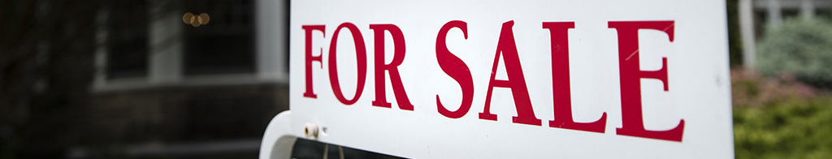

## Background

##### **What’s going on here?**

> [Kaggle.com](https://www.kaggle.com/) is one website among many that hosts “data challenges” where participants can compete for the “best” model to predict some sort of variable or outcome. Many of these competitions award cash prizes of thousands of dollars to the winning team. These are often listed as “machine learning” competitions, but regression models (like the one I built in this document) can often be among the top models as well. In this project is my own attempt at producing a significant linear regression model that could predict with some accuracy the averaage price of a home if it has a certain number of significant traits. Throughout the project documentation you will find my work, code, and explaination of what I did and how I made a significant model for Kaggle.

[figure not shown]

## Linear Regression Models

##### **After one hot and encoding some important variables, I’m ready to find the model with the best fit.**

> In finding the best model to fit this data set, I went through eleven different iterations in search of the best model.

##### **The Ideal Model**

> The first model is the one I chose to use for my final model. It has an ajusted R-squared value of **0.8605** and a validation R-squared value of **0.8479917**. This makes the model in the upper tier for the grade on this assignment. It is not the best R-squared value I came up with either. Some of those other models are below and their captions explain what they entail. In short, I chose the first model because it is completely two-dimensional and is easy to interpet. The others… well not so easy.

##### **The model I chose to run with.**

|  | Estimate | Std. Error | t value | Pr(>\|t\|) |
| --- | --- | --- | --- | --- |
| **(Intercept)** | 5.988 | 8.549 | 0.7004 | 0.4838 |
| **TSF** | 0.02245 | 0.002486 | 9.033 | 5.219e-19 |
| **I(TSF^3)** | 6.831e-10 | 6.256e-11 | 10.92 | 9.904e-27 |
| **QLTY6** | 17.03 | 2.133 | 7.984 | 2.865e-15 |
| **QLTY7** | 41.44 | 2.469 | 16.78 | 6.838e-58 |
| **QLTY8** | 70.1 | 3.335 | 21.02 | 9.006e-86 |
| **QLTY9** | 131 | 5.437 | 24.09 | 4.46e-108 |
| **QLTY10** | 155.1 | 9.117 | 17.01 | 2.809e-59 |
| **FB3** | 19.86 | 5.977 | 3.324 | 0.000911 |
| **PavedY** | 13.09 | 3.069 | 4.264 | 2.137e-05 |
| **FunM1** | 28.28 | 8.574 | 3.298 | 0.0009975 |
| **FunM2** | 28.56 | 8.421 | 3.392 | 0.000713 |
| **FunMod** | 20.06 | 10.18 | 1.971 | 0.04891 |
| **FunT** | 36.37 | 6.728 | 5.405 | 7.554e-08 |
| **GQ5** | 8.442 | 2.86 | 2.952 | 0.003213 |

Best Model: Outliers Removed ~ 2-D

| Observations | Residual Std. Error | $R^2$ | Adjusted $R^2$ |
| --- | --- | --- | --- |
| 1458 | 29.7 | 0.8618 | 0.8605 |

|  | Estimate | Std. Error | t value | Pr(>\|t\|) |
| --- | --- | --- | --- | --- |
| **(Intercept)** | -32.16 | 8.764 | -3.669 | 0.0002522 |
| **TSF** | 0.05413 | 0.003478 | 15.56 | 1.349e-50 |
| **I(TSF^3)** | -1.08e-09 | 1.466e-10 | -7.368 | 2.91e-13 |
| **QLTY10** | 56.38 | 15.15 | 3.723 | 0.0002048 |
| **QLTY8** | 29.56 | 5.682 | 5.202 | 2.254e-07 |
| **QLTY7** | 13.72 | 3.837 | 3.577 | 0.0003593 |
| **FB3** | 19.26 | 5.715 | 3.37 | 0.0007707 |
| **PavedY** | 10.57 | 2.939 | 3.597 | 0.0003332 |
| **FunM1** | 23.49 | 8.218 | 2.859 | 0.004314 |
| **FunM2** | 26.56 | 8.079 | 3.288 | 0.001033 |
| **FunMod** | 28.59 | 9.741 | 2.934 | 0.003394 |
| **FunT** | 31.87 | 6.461 | 4.933 | 9.054e-07 |
| **GQ5** | 6.775 | 2.746 | 2.467 | 0.01375 |
| **I(TSF^3):QLTY6** | 7.289e-10 | 7.132e-11 | 10.22 | 1.014e-23 |
| **I(TSF^3):QLTY7** | 9.986e-10 | 1.067e-10 | 9.361 | 2.941e-20 |
| **I(TSF^3):QLTY8** | 1.201e-09 | 1.124e-10 | 10.69 | 1.065e-25 |
| **I(TSF^3):QLTY9** | 2.092e-09 | 8.591e-11 | 24.35 | 5.326e-110 |
| **I(TSF^3):QLTY10** | 1.611e-09 | 1.346e-10 | 11.97 | 1.582e-31 |

Best Model: With Crazy Confusion Interactions

| Observations | Residual Std. Error | $R^2$ | Adjusted $R^2$ |
| --- | --- | --- | --- |
| 1458 | 28.34 | 0.8744 | 0.8729 |

|  | Estimate | Std. Error | t value | Pr(>\|t\|) |
| --- | --- | --- | --- | --- |
| **(Intercept)** | 28.8 | 7.242 | 3.977 | 7.328e-05 |
| **I(TSF^2)** | 7.242e-06 | 1.886e-07 | 38.4 | 6.036e-223 |
| **QLTY6** | 17.44 | 2.093 | 8.331 | 1.84e-16 |
| **QLTY7** | 41.25 | 2.375 | 17.37 | 1.632e-61 |
| **QLTY8** | 68.46 | 3.328 | 20.57 | 1.077e-82 |
| **QLTY9** | 128.5 | 5.487 | 23.43 | 3.675e-103 |
| **QLTY10** | 156 | 8.761 | 17.8 | 2.981e-64 |
| **FB3** | 20.18 | 5.705 | 3.538 | 0.0004165 |
| **FunM1** | 30.81 | 8.61 | 3.578 | 0.0003577 |
| **FunM2** | 29.83 | 8.466 | 3.523 | 0.0004397 |
| **FunMod** | 20.46 | 10.24 | 1.999 | 0.04579 |
| **FunT** | 38.46 | 6.76 | 5.689 | 1.545e-08 |
| **PavedY** | 16.3 | 2.933 | 5.558 | 3.251e-08 |
| **I(TSF^2):Outliers** | -7.785e-06 | 2.231e-07 | -34.9 | 4.35e-194 |

Model Using Outliers: ~ 2-D

| Observations | Residual Std. Error | $R^2$ | Adjusted $R^2$ |
| --- | --- | --- | --- |
| 1460 | 29.88 | 0.8598 | 0.8585 |

|  | Estimate | Std. Error | t value | Pr(>\|t\|) |
| --- | --- | --- | --- | --- |
| **(Intercept)** | -292.1 | 30.88 | -9.459 | 1.213e-20 |
| **I(TSF^2)** | 7.213e-06 | 1.828e-07 | 39.46 | 9.192e-232 |
| **I(YearBuilt^2)** | 8.829e-05 | 7.989e-06 | 11.05 | 2.578e-27 |
| **QLTY6** | 13.87 | 2.066 | 6.715 | 2.696e-11 |
| **QLTY7** | 31.1 | 2.522 | 12.33 | 2.615e-33 |
| **QLTY8** | 55.89 | 3.463 | 16.14 | 5.462e-54 |
| **QLTY9** | 113.1 | 5.532 | 20.44 | 9.244e-82 |
| **QLTY10** | 145 | 8.564 | 16.94 | 7.915e-59 |
| **FB3** | 24.05 | 5.547 | 4.335 | 1.558e-05 |
| **FunM1** | 32.2 | 8.345 | 3.859 | 0.000119 |
| **FunM2** | 31.59 | 8.216 | 3.844 | 0.0001261 |
| **FunMod** | 19.67 | 9.929 | 1.981 | 0.04774 |
| **FunT** | 36.34 | 6.564 | 5.536 | 3.662e-08 |
| **I(TSF^2):Outliers** | -7.804e-06 | 2.163e-07 | -36.09 | 7.089e-204 |

Model Using Outliers: YearBuilt added ~ 3-D

| Observations | Residual Std. Error | $R^2$ | Adjusted $R^2$ |
| --- | --- | --- | --- |
| 1460 | 29 | 0.8679 | 0.8667 |

##### **Diagnostic Plots**

Using the diagnostic plots; residuals vs fitted, Cook’s distance, and the residuals vs leverage, there is a better understanding of whats going on in the data. It seems like there are some odd homes that are affecting the linear model in the leverage plot because they are so far away form the majority of the data. But the leverage created by it is not so bad that the model is poor. To note as well, there are a few different homes that have really lardge Cook distances. But then again, they wont change the model too much.

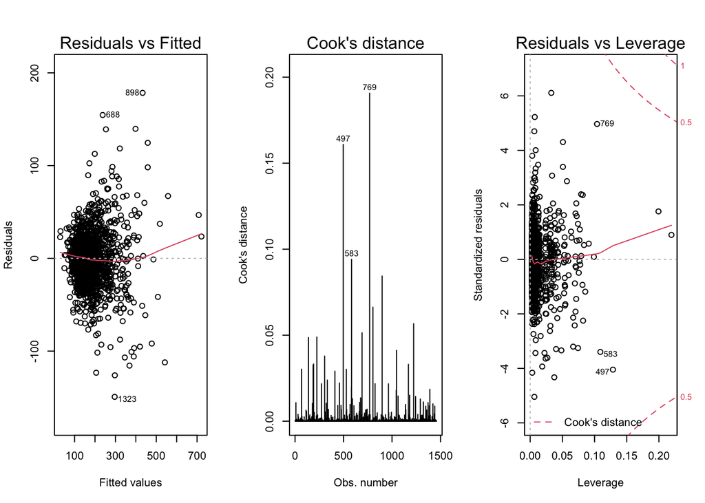

## Interpretation

### What variables add the most to the cost of a home?

##### **Variables or home traits and how much they add to the average base price (Thousands):**

Table continues below

| I(TSF^3) | TSF | (Intercept) | GQ5 | PavedY | QLTY6 | FB3 | FunMod |
| --- | --- | --- | --- | --- | --- | --- | --- |
| 0 | 0.02245 | 5.988 | 8.442 | 13.09 | 17.03 | 19.86 | 20.06 |

| FunM1 | FunM2 | FunT | QLTY7 | QLTY8 | QLTY9 | QLTY10 |
| --- | --- | --- | --- | --- | --- | --- |
| 28.28 | 28.56 | 36.37 | 41.44 | 70.1 | 131 | 155.1 |

##### **The Significant Variables:**

#### Overall Quality

##### **Significance of Overall Quality**

> The variable overall quality proved to be the best indicator of a home increasing in value other than actual total square footage. There are 10 different quality levels, but t=only level 6-10 were significant. This variable changing the average price of a home is actually really interpretable in that a home can only have one level at a time, so in this model there are five increases in price depending on what quality rating a home is given. The graph below does a good job at demonstrating that the quality of home increases the value of home. Each level is color coded.

##### **Base Line and Max Line**

> One more thing to note: The lowest grey dashed line is the base line or the line that describes the average cost of a home without any of the significat values of this home being included in it. At the top of the graph, the dashed line shows the max average home price if all the switches are turned on. This will make much more sense as we delve into the other variables included in the model.

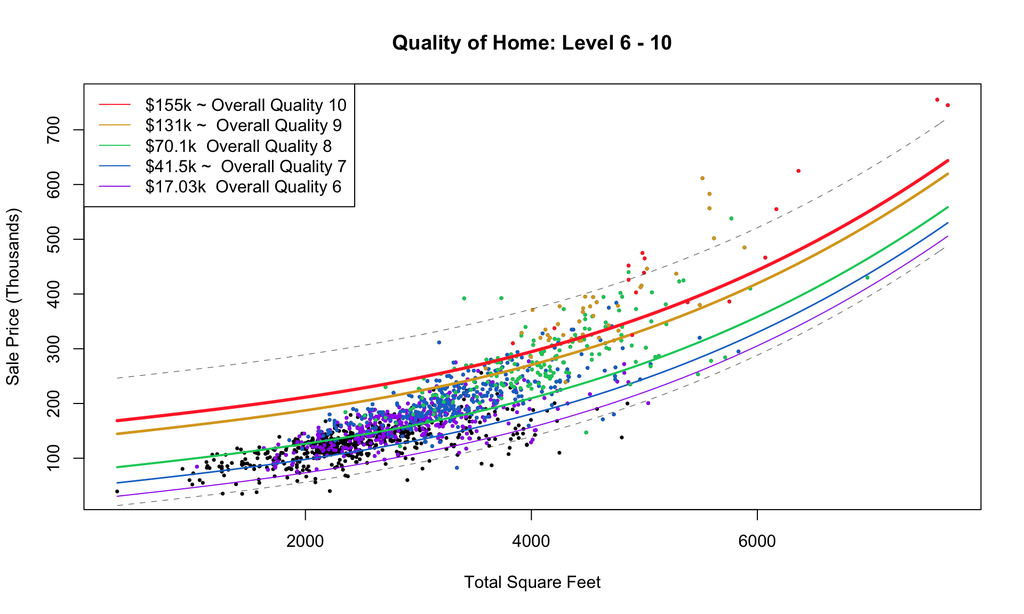

#### Home Functionality

##### **Functionality? What’s that**

> The variable functionality is described as a homes level of defects. The less the better with the level of typical being a good predictor of increasing home price. The other great thing about this value is that a home can only contain one of them at a time. So, if home has a typical functionality level and a overall quality of six then those two increases in price are actually compounded together and help the average price of a home inch higher to the max average value it could acheive.

##### **Different Levels of Functionality**

> In the graph below there are four differnt levels being added to the base home price line. Typical, Moderate, Minor Deductions 1, and Minor Deductions 2. Its apparent that many homes fall into the typical functional classification, but thats okay becasue the interpretation is still very significant. When a home had typical defects then its average sale price goes up by **$36,000** which is very significant.

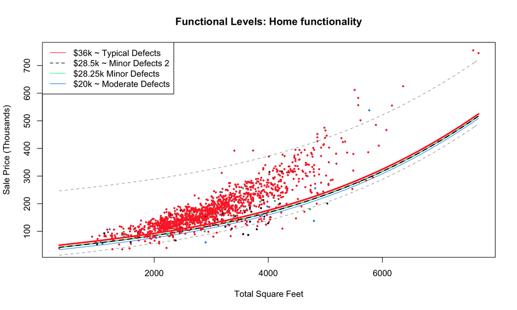

#### Miscellaneous Significant Variables

##### **Randomness or usefulness…**

> In such a large data set, there are certaily going to be some variables that do not add any interpretation or significance to a model as the one that is being interpreted here. But sometimes there are some small but significant flakes of gold found that add a significant enough amount of money to a homes price, especially when compounded together.

##### **What can be used.**

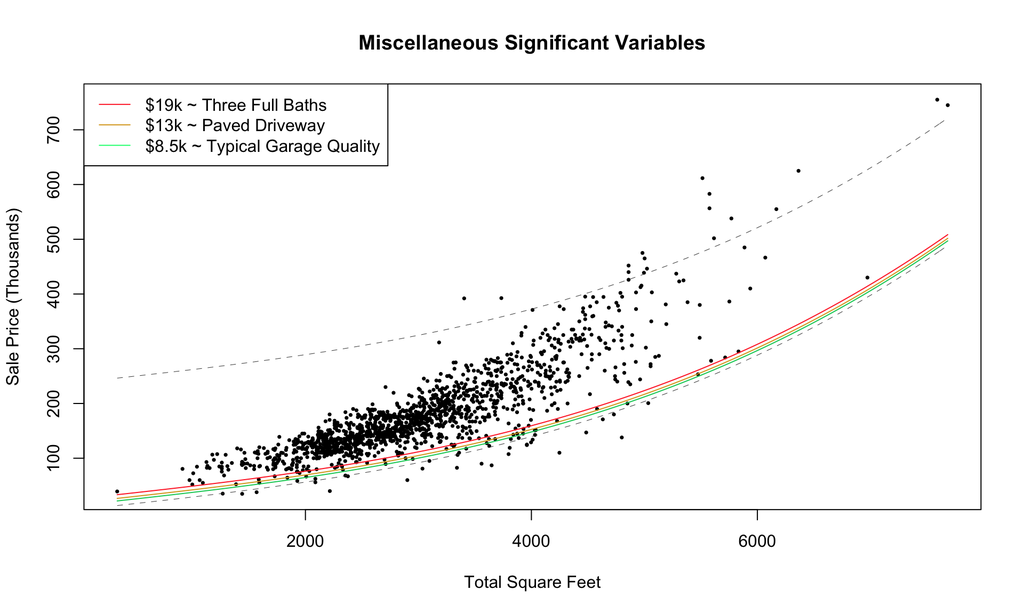

## Wrapping up.

> Again even though this model is simple it does good enough of a job guessing the average price of a home that has these certain variables associated with it. That being said if a home has none of these variables then chances are the average price is closer to that base line that there is no reason to assume it worth any more than it is there. The model also shows that if a home has the best overall quality, the best function, and all the other significant swithches. it can have an increase of **$238,445** from its base price. This is a great predictor and shows that top dashed grey in all the plots seen before. Again this will not predict everything, but for the interest of this project, and for making a complex problem more understandable, this model does a wonderful job.